# Examination of European Covd Cases from 2020-2022

Ian Rector

A data dictionary for the dataset is available [here](https://www.ecdc.europa.eu/sites/default/files/documents/Description-and-disclaimer_daily_reporting.pdf).

#### Definitions:

- “Incidence rate” is equal to new daily cases per 100K individuals. Country population estimates can be found in ‘popData2020.’ You will calculate a daily incidence rate in item (1), for each country, that we will explore further in items (2) and (3).
- “Fatality rate” is equal to new daily deaths per 100K individuals. Country population estimates can be found in ‘popData2020.’ You will calculate a daily fatality rate in item (1), for each country, that we will explore further in items (2) and (3).

#### 1. Descriptive Statistics

```r
data <- data %>% replace_na(list(cases = 0, deaths = 0)) %>% mutate(cases = ifelse(cases < 0, 0, cases), deaths = ifelse(deaths < 0, 0, deaths))

data$incidence_rate = data$cases/data$popData2020*100000
data$fatality_rate = data$deaths/data$popData2020*100000
```

```r
set.seed(123)
sample_country = sample(levels(data$countriesAndTerritories),5)
sample_country = c(sample_country,"Germany","France")
sample_country
```

```
## [1] "Ireland"   "Lithuania" "Iceland"   "Bulgaria"  "France"    "Germany"
## [7] "France"
```

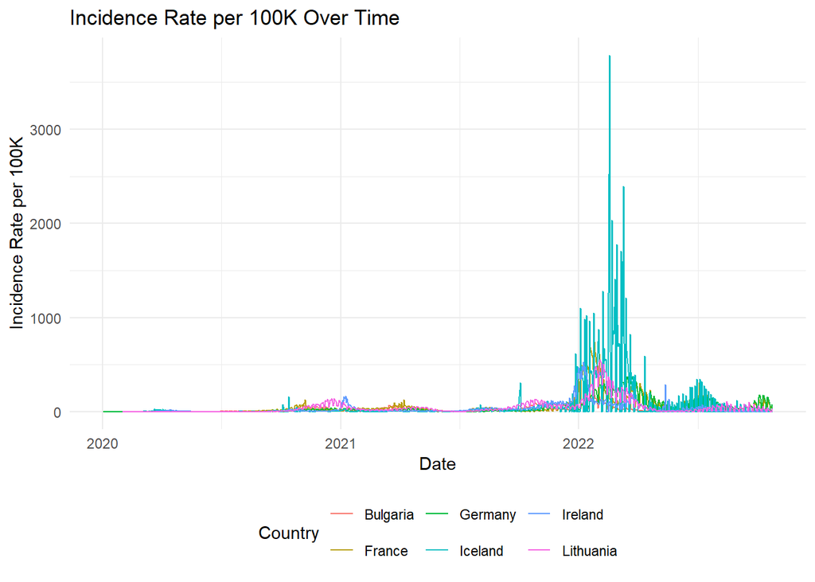

```r
sample_data <- subset(data, countriesAndTerritories %in% sample_country)

# Visualization of dataRep and incidence_rate

sample_data$dateRep <- as.Date(sample_data$dateRep)
ggplot_plot <- ggplot(sample_data, aes(x = dateRep, y = incidence_rate, group = countriesAndTerritories, color = countriesAndTerritories)) +
   geom_line() +
   theme_minimal() +
   labs(title = "Incidence Rate per 100K Over Time", x = "Date", y = "Incidence Rate per 100K") +
   scale_color_discrete(name = "Country") +
   theme(legend.position = "bottom")

 print(ggplot_plot)
```

This is the visualization of the incidence rate of six different countries. The x-axis represents the time, beginning from the year 2020 and extending into 2022. The y-axis shows the incidence rate per 100k people. Each line with different color represents a different country. We can see very low and stable rates in all countries from 2020 to the end of 2021. At the beginning of 2022, the lines become very dense indicating a spike in incidence in a short period of time during this period. Iceland in particular we can see that the incidence has basically peaked. COVID-19 changed from Delta to Omicron and increased its transmission capacity during this period. Omicron accounts for 90% of cases in Iceland and has led to a surge in the incidence in Iceland. But in other countries it has increased but it is still well controlled.

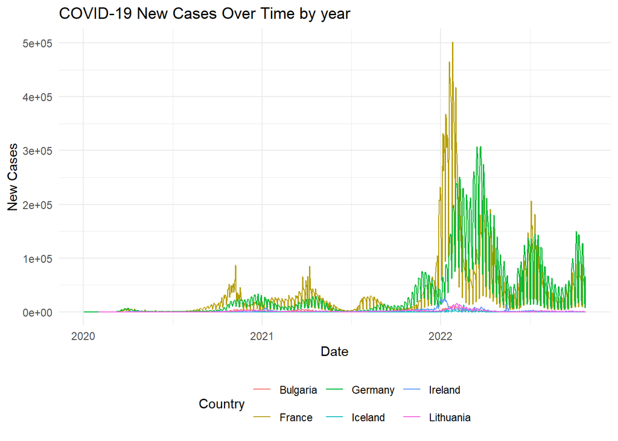

```r
# Visualization of dataRep and cases breaks by year
 ggplot_plot <- ggplot(sample_data, aes(x = dateRep, y = cases, group = countriesAndTerritories, color = countriesAndTerritories)) +
   geom_line() +
   theme_minimal() +
   labs(title = "COVID-19 New Cases Over Time by year", x = "Date", y = "New Cases") +
   scale_color_discrete(name = "Country") +
   theme(legend.position = "bottom")
 print(ggplot_plot)
```

This chart shows new cases over time. The trends are the same as the chart for incidence rate, but it is measuring total cases rather than cases per 100k, so countries like France, which are more populous have many more cases than Iceland even though Iceland has a higher incidence rate in 2022.

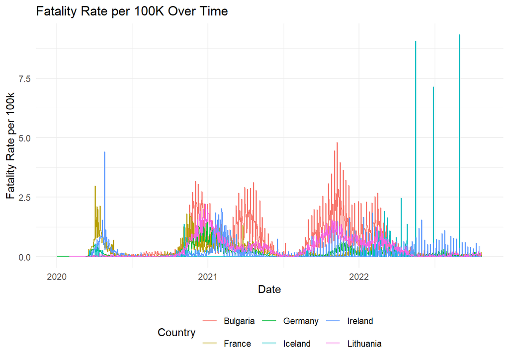

```r
#Visulization of dataRep and fatality_rate
ggplot_plot <- ggplot(sample_data, aes(x = dateRep, y = fatality_rate, group = countriesAndTerritories, color = countriesAndTerritories)) +
  geom_line() +
  theme_minimal() +
  labs(title = "Fatality Rate per 100K Over Time", x = "Date", y = "Fatality Rate per 100k") +
  scale_color_discrete(name = "Country") +
  theme(legend.position = "bottom")

print(ggplot_plot)
```

The second visualization is about the time and the fatality rate with these six countries. We can see that the fluctuation of the line is still very obvious, and it is in a rising state at the beginning of each year, mainly because the cold weather at the beginning of the year leads to a higher probability of virus transmission and a higher mortality rate. In the period from 2021 to 2022, Bulgaria has the highest mortality rate, both because of the Delta strain and because Bulgaria’s health expenditure per capita is very low compared to other European countries, so its health conditions are not as good as those of other European countries. And by 2022, Iceland’s death rate starts to skyrocket and that echoes the first graph.

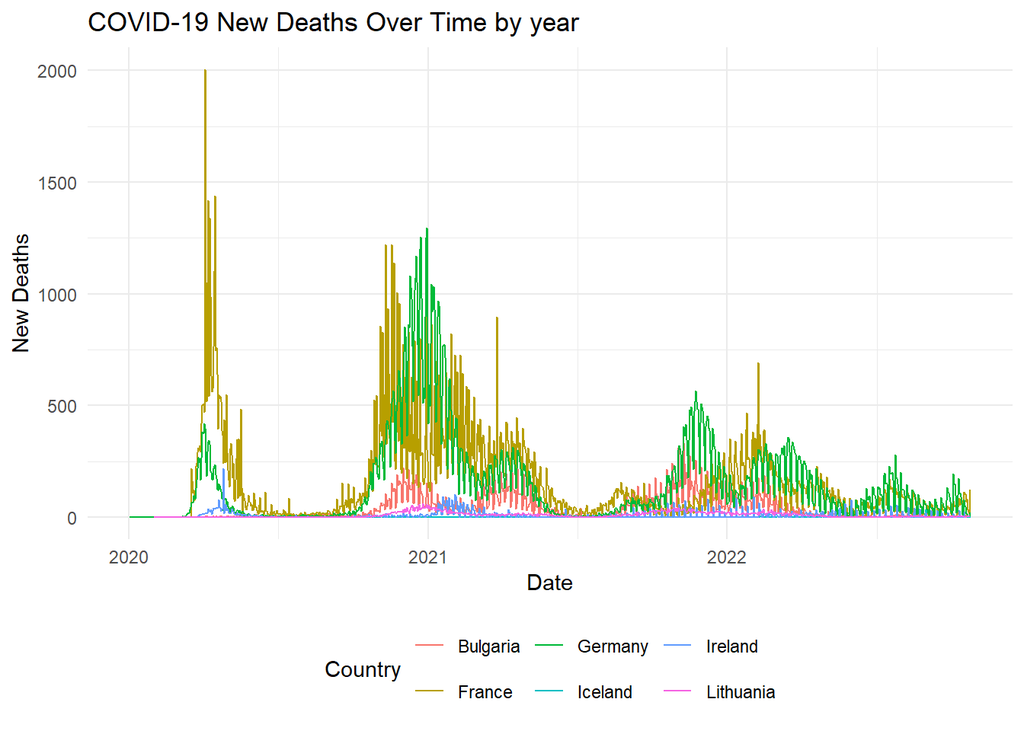

```r
#Visulization of dataRep and New deaths
ggplot_plot <- ggplot(sample_data, aes(x = dateRep, y = deaths, group = countriesAndTerritories, color = countriesAndTerritories)) +
  geom_line() +
  theme_minimal() +
  labs(title = "COVID-19 New Deaths Over Time by year", x = "Date", y = "New Deaths") +
  scale_color_discrete(name = "Country") +
  theme(legend.position = "bottom")

print(ggplot_plot)
```

As with total cases, Frace and Germany have by far the most deaths because they are the most populous. This makes the previous graph a better proxy for the devastation of Covid and for evaluating the health systems of these six nations.

```r
total_cases_deaths <- aggregate(cbind(total_cases = cases, total_deaths = deaths) ~ countriesAndTerritories, data, sum)
total_cases_deaths
```

```
##    countriesAndTerritories total_cases total_deaths
## 1                  Austria     5402162        20899
## 2                  Belgium     4607296        32883
## 3                 Bulgaria     1275481        37790
## 4                  Croatia     1244692        17085
## 5                   Cyprus      599500         1191
## 6                  Czechia     4152997        41524
## 7                  Denmark     3221572         7274
## 8                  Estonia      606268         2739
## 9                  Finland     1335318         6407
## 10                  France    36962242       156758
## 11                 Germany    35287690       152753
## 12                  Greece     5138059        33574
## 13                 Hungary     2141513        47938
## 14                 Iceland      207102          214
```

[output cut: 16 more lines]

```r
total_cases_deaths$case_fatality_rate <- with(total_cases_deaths, (total_deaths / total_cases) * 100)
total_cases_deaths$case_fatality_rate
```

```
##  [1] 0.3868636 0.7137158 2.9628038 1.3726287 0.1986656 0.9998562 0.2257904
##  [8] 0.4517804 0.4798108 0.4241031 0.4328790 0.6534374 2.2385108 0.1033307
## [15] 0.4785870 0.7648344 0.6367119 0.4185322 0.7413750 0.3800273 0.7008718
## [22] 0.2680611 0.2862039 1.9072432 0.4557273 2.0692236 0.8089356 0.5597545
## [29] 0.8412200 0.7834184
```

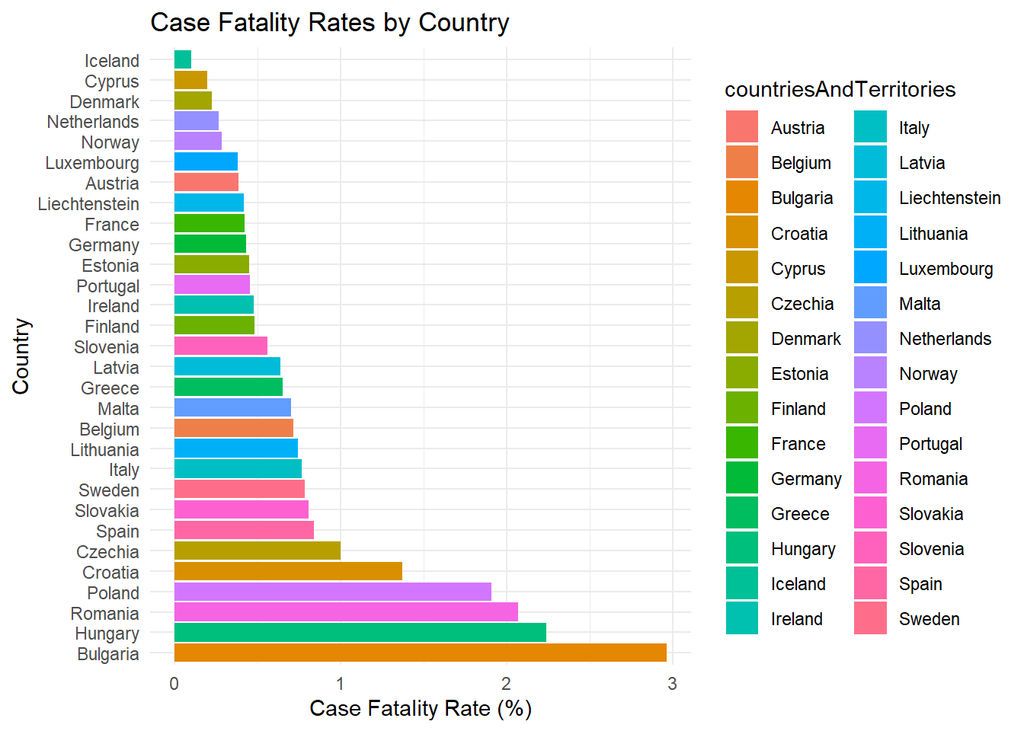

```r
ggplot(total_cases_deaths, aes(x = reorder(countriesAndTerritories, -case_fatality_rate), y = case_fatality_rate, fill = countriesAndTerritories)) +
  geom_bar(stat = "identity") +
  theme_minimal() +
  labs(title = "Case Fatality Rates by Country", x = "Country", y = "Case Fatality Rate (%)") +
  coord_flip()
```

This chart displays case fatality rates by country, presenting a snapshot of the lethality of Covid in different countries. Overall, Iceland had the lowest fatality rate and Bulgaria the highest, suggesting that some countries may have a high number of cases, but their health systems can cope with this surge without a corresponding spike in mortality. Conversely, a high case fatality rate may indicate that, despite the low number of cases, the health care system is less effective at treating the disease.

#### 2. Inferential Statistics

Direct comparison of France and Germany since they are large continental western European nations, so this means they should serve as a good comparison.

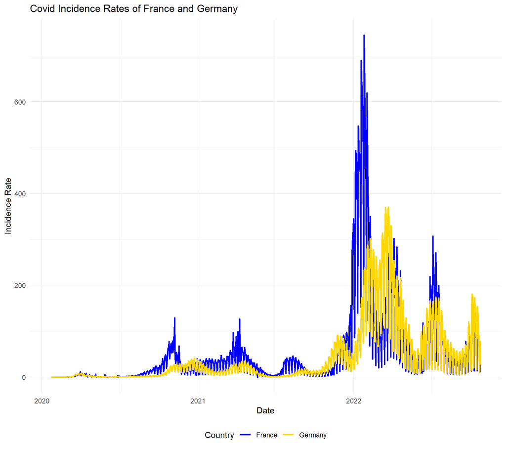

```r
indexF <- which(data$countriesAndTerritories=="France")
indexG <- which(data$countriesAndTerritories=="Germany")
dataF <- data[indexF,]
dataG <- data[indexG,]
merged_data <- merge(dataF, dataG, by.x = "dateRep", by.y = "dateRep", all = FALSE)
columns_to_keep <- c("dateRep", "incidence_rate.x","incidence_rate.y")

df <- merged_data[, columns_to_keep, drop = FALSE]
colnames(df) <- c("Date","incidence_rate_France","incidence_rate_Germany")


ggplot(df, aes(x=Date)) +
  geom_line(aes(y=incidence_rate_France, color = "France"), size = 1) +
  geom_line(aes(y=incidence_rate_Germany, color = "Germany"), size = 1) +
  theme_minimal() +
  labs(x = "Date", y = "Incidence Rate", title = "Covid Incidence Rates of France and Germany", color = "Country") +
  scale_color_manual(values = c("France" = "blue", "Germany" = "gold")) +
  theme(legend.position = "bottom")
```

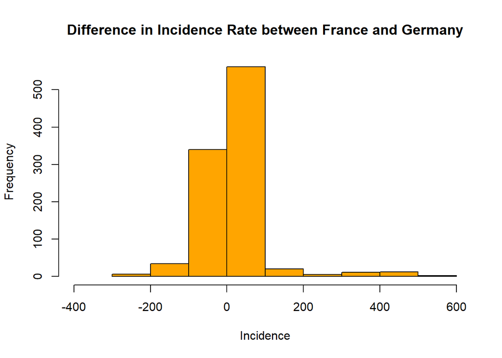

```r
hist(df$incidence_rate_France-df$incidence_rate_Germany,xlab="Incidence",col="orange",main="Difference in Incidence Rate between France and Germany", xlim=c(-400,600))
```

```r
bartlett.test(list(df$incidence_rate_France,df$incidence_rate_Germany))
```

```
##
##  Bartlett test of homogeneity of variances
##
## data:  list(df$incidence_rate_France, df$incidence_rate_Germany)
## Bartlett's K-squared = 128.7, df = 1, p-value < 2.2e-16
```

The data is paired by date, so a paired t test should be used. France and Germany have 991 dates in which they recorded new Covid cases, so those are the dates we use. The differences between the incidence rates in France and Germany do not resemble a normal distribution, so the Wilcoxon signed rank test should be used instead of a paired t-test.

Null Hypothesis: There is no difference in the median incidence rates of France and Germany. Alternative Hypothesis: There is a difference in the median incidence rates of France and Germany.

An alpha of 0.05 should be used.

```r
wilcox.test(df$incidence_rate_France, df$incidence_rate_Germany, paired = TRUE, conf.int = TRUE, conf.level = 0.95)
```

```
##
##  Wilcoxon signed rank test with continuity correction
##
## data:  df$incidence_rate_France and df$incidence_rate_Germany
## V = 313471, p-value = 5.822e-14
## alternative hypothesis: true location shift is not equal to 0
## 95 percent confidence interval:
##  3.338357 6.905412
## sample estimates:
## (pseudo)median
##       5.089616
```

We reject the null hypothesis since the p-value is well below the selected alpha of 0.05.

#### 3. Correlation

Correlations of overall statistics between countries.

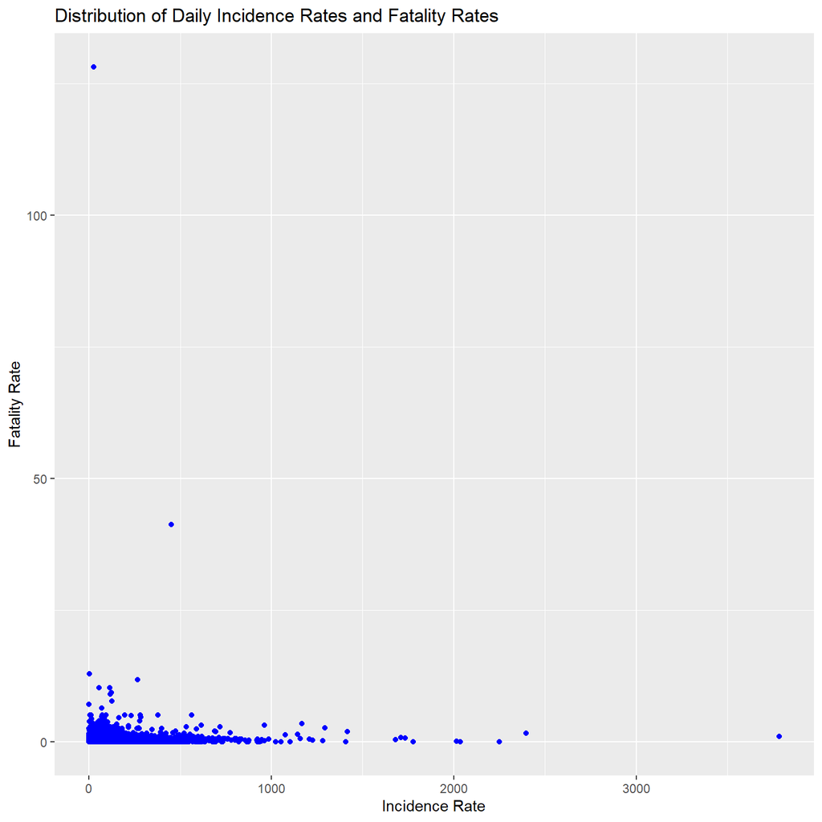

```r
ggplot(data, aes(x = incidence_rate, y = fatality_rate)) +
  geom_point(color = "blue") +
  labs(title = "Distribution of Daily Incidence Rates and Fatality Rates", x = "Incidence Rate", y = "Fatality Rate")
```

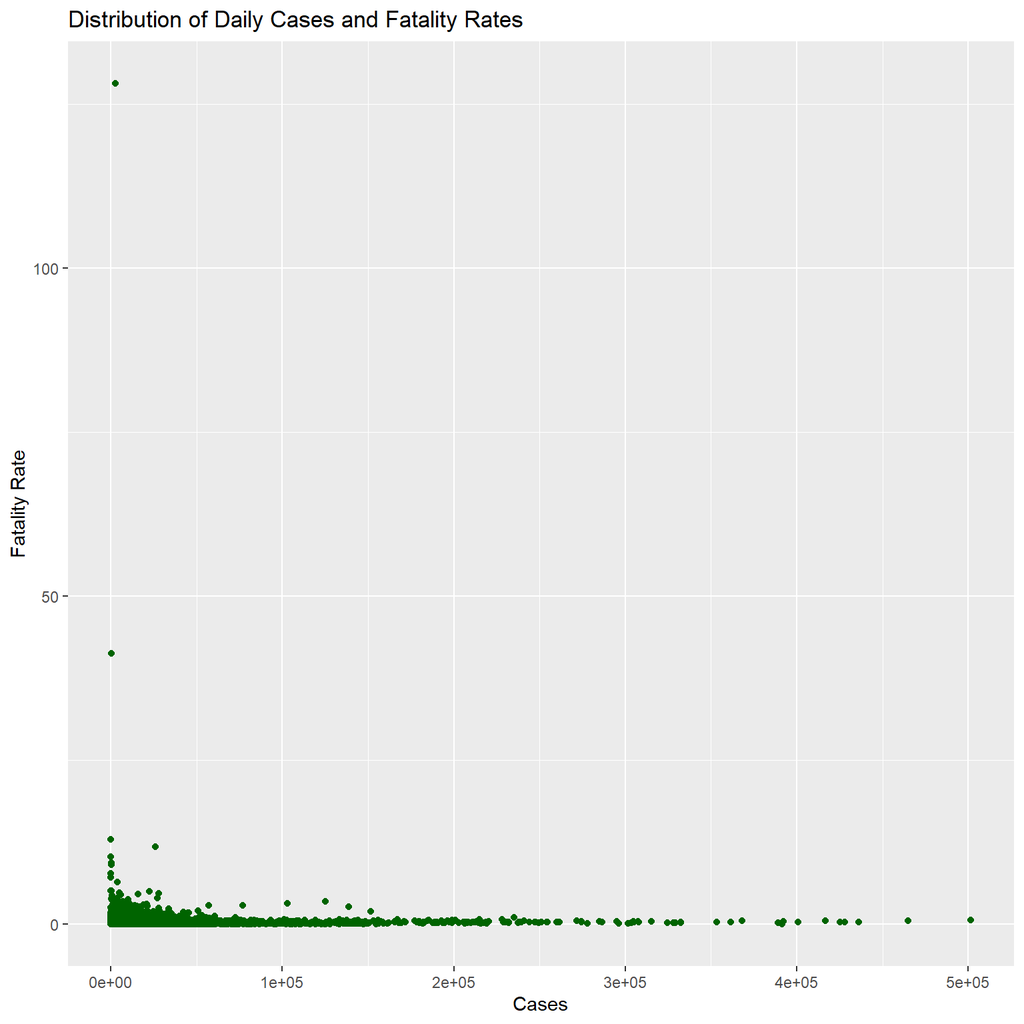

```r
ggplot(data, aes(x = cases, y = fatality_rate)) +
  geom_point(color = "darkgreen") +
  labs(title = "Distribution of Daily Cases and Fatality Rates", x = "Cases", y = "Fatality Rate")
```

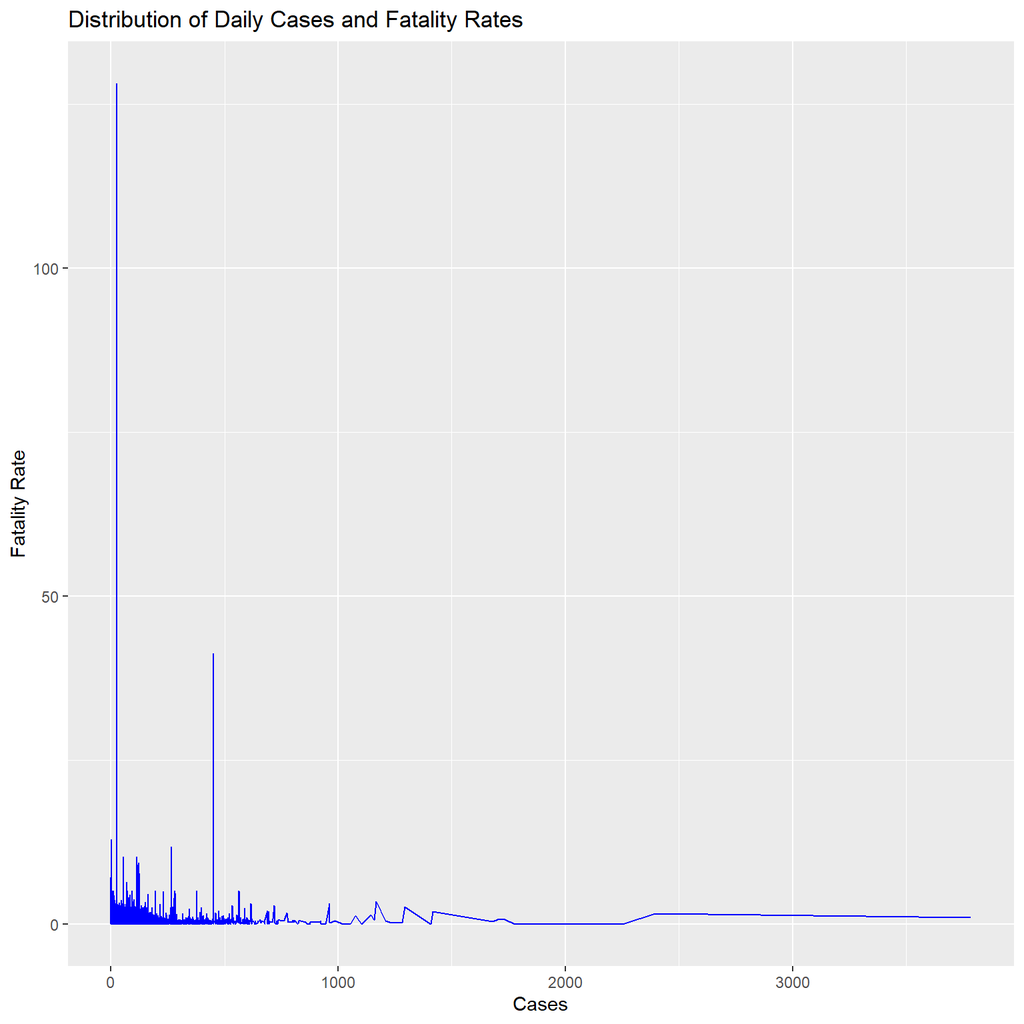

```r
ggplot(data, aes(x = incidence_rate, y = fatality_rate)) +
  geom_line(color = "blue") +
  labs(title = "Distribution of Daily Cases and Fatality Rates", x = "Cases", y = "Fatality Rate")
```

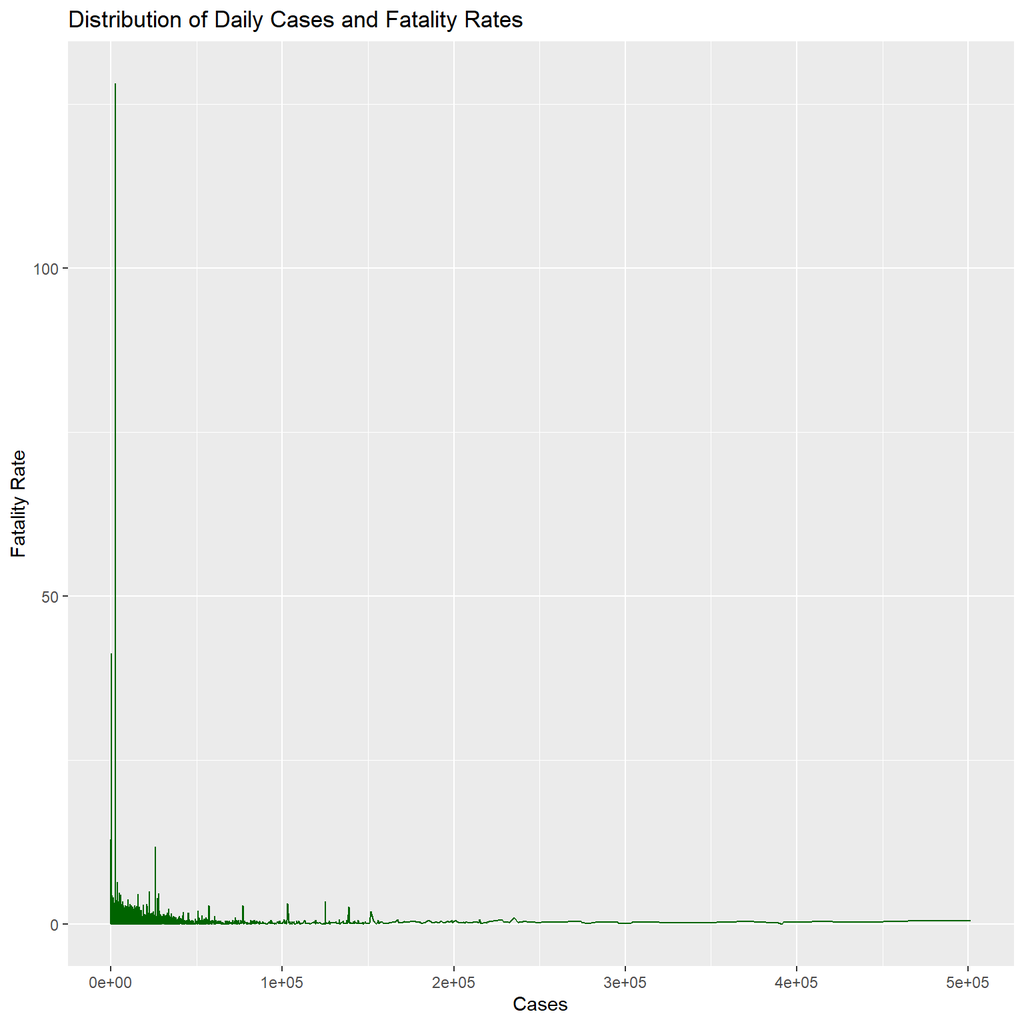

```r
ggplot(data, aes(x = cases, y = fatality_rate)) +
  geom_line(color = "darkgreen") +
  labs(title = "Distribution of Daily Cases and Fatality Rates", x = "Cases", y = "Fatality Rate")
```

```r
pearson_cor <- cor(data$incidence_rate, data$fatality_rate, method = "pearson")
kendall_cor <- cor(data$incidence_rate, data$fatality_rate, method = "kendall")
spearman_cor <- cor(data$incidence_rate, data$fatality_rate, method = "spearman")
cat("Pearson Correlation:", pearson_cor, "\n")
```

```
## Pearson Correlation: 0.1097366
```

```r
cat("Spearman Correlation:", spearman_cor, "\n")
```

```
## Spearman Correlation: 0.5694821
```

```r
cat("Kendall Tau Correlation:", kendall_cor, "\n")
```

```
## Kendall Tau Correlation: 0.4135004
```

A short statement identifying the most appropriate correlation coefficient.

-Pearson Correlation Coefficient: -Measures the linear relationship between two variables. -Assumes that both variables are normally distributed and have a linear relationship. -The correlation coefficient of 0.1097366 suggests a very weak linear relationship. -Spearman Rank Correlation Coefficient: -A non-parametric measure that assesses how well the relationship between two variables can be described by a monotonic function (not necessarily linear. -Does not assume normal distribution and is more appropriate for ordinal data or non-linear relationships. -The correlation coefficient of 0.5694821 indicates a moderate positive monotonic relationship. -Kendall Tau Correlation Coefficient: -Another non-parametric measure that assesses the strength of a monotonic relationship. -It’s more robust and less sensitive to errors or outliers compared to Pearson and Spearman. -The correlation coefficient of 0.4135004 suggests a moderate positive association, though weaker than Spearman’s correlation.

Given these points, the Spearman Rank Correlation Coefficient appears to be the most appropriate for our analysis. The first reason is if the relationship between daily incidence and fatality rates is not strictly linear or if the data does not follow a normal distribution, Spearman’s correlation is more suitable. The second reason is Spearman’s correlation is less sensitive to outliers compared to Pearson’s correlation. The third reason is the Spearman correlation value (0.5694821) is significantly higher than the Pearson value, indicating a stronger association in a monotonic sense. In conclusion, given the moderate positive value of the Spearman correlation and its suitability for potentially non-linear and non-normally distributed data, it is the most appropriate choice for assessing the relationship between daily COVID-19 incidence and fatality rates in our dataset.

#### 4. Regression

Here, we will fit a model on data from twenty (20) countries considering total new cases as a function of population, population density and gross domestic product (GDP) per capita. Note that the GDP per capita is given in “purchasing power standard,” which considers the costs of goods and services in a country relative to incomes in that country; i.e. we will consider this as appropriately standardized.

Code is given below defining a new data frame, ‘model_df,’ which provides the total area and standardized GDP per capita for the twenty (20) countries for our model fit.

```r
twenty_countries <- c("Austria", "Belgium", "Bulgaria", "Cyprus", "Denmark",
                      "Finland", "France", "Germany", "Hungary", "Ireland",
                      "Latvia", "Lithuania", "Malta", "Norway", "Poland",
                      "Portugal", "Romania", "Slovakia", "Spain", "Sweden")

sq_km <- c(83858, 30510, 110994, 9251, 44493, 338145, 551695, 357386, 93030,
           70273, 64589, 65300, 316, 385178, 312685, 88416, 238397, 49036,
           498511, 450295)

gdp_pps <- c(128, 118, 51, 91, 129, 111, 104, 123, 71, 190, 69, 81, 100, 142,
             71, 78, 65, 71, 91, 120)

model_df <- data %>%
  select(c(countriesAndTerritories, popData2020)) %>%
  filter(countriesAndTerritories %in% twenty_countries) %>%
  distinct(countriesAndTerritories, .keep_all = TRUE) %>%
  add_column(sq_km, gdp_pps) %>%
  mutate(pop_dens = popData2020 / sq_km) %>%
  rename(country = countriesAndTerritories, pop = popData2020)
```

Next, we need to add one (1) more column to our ‘model_df’ data frame. Specifically, one that has the total number of new cases for each of the twenty (20) countries. We calculate the total number of new cases by summing all the daily new cases, for each country, across all the days in the dataset.

```r
### The following code will be removed for students to complete the work themselves.

total_cases <- data %>%
  select(c(countriesAndTerritories, cases)) %>%
  group_by(countriesAndTerritories) %>%
  dplyr::summarize(total_cases = sum(cases, na.rm = TRUE)) %>%
  filter(countriesAndTerritories %in% twenty_countries) %>%
  select(total_cases)

model_df <- model_df %>%
  add_column(total_cases)
```

Now, we will fit our model using the data in ‘model_df.’ We are interested in explaining total cases (response) as a function of population (explanatory), population density (explanatory), and GDP (explanatory).

```r
model1 = lm(total_cases~.,model_df[,-1])
summary(model1)
```

```
##
## Call:
## lm(formula = total_cases ~ ., data = model_df[, -1])
##
## Residuals:
##      Min       1Q   Median       3Q      Max
## -8164687  -770205   253808  1293224  9473515
##
## Coefficients:
##               Estimate Std. Error t value Pr(>|t|)
## (Intercept) -3.491e+06  2.868e+06  -1.217    0.242
## pop          4.557e-01  5.129e-02   8.886 2.31e-07 ***
## sq_km       -5.340e+00  6.917e+00  -0.772    0.452
## gdp_pps      3.121e+04  2.619e+04   1.192    0.252
## pop_dens     9.569e+00  2.600e+03   0.004    0.997
## ---
## Signif. codes:  0 '***' 0.001 '**' 0.01 '*' 0.05 '.' 0.1 ' ' 1
##
## Residual standard error: 3755000 on 15 degrees of freedom
## Multiple R-squared:  0.9002, Adjusted R-squared:  0.8736
## F-statistic: 33.83 on 4 and 15 DF,  p-value: 2.411e-07
```

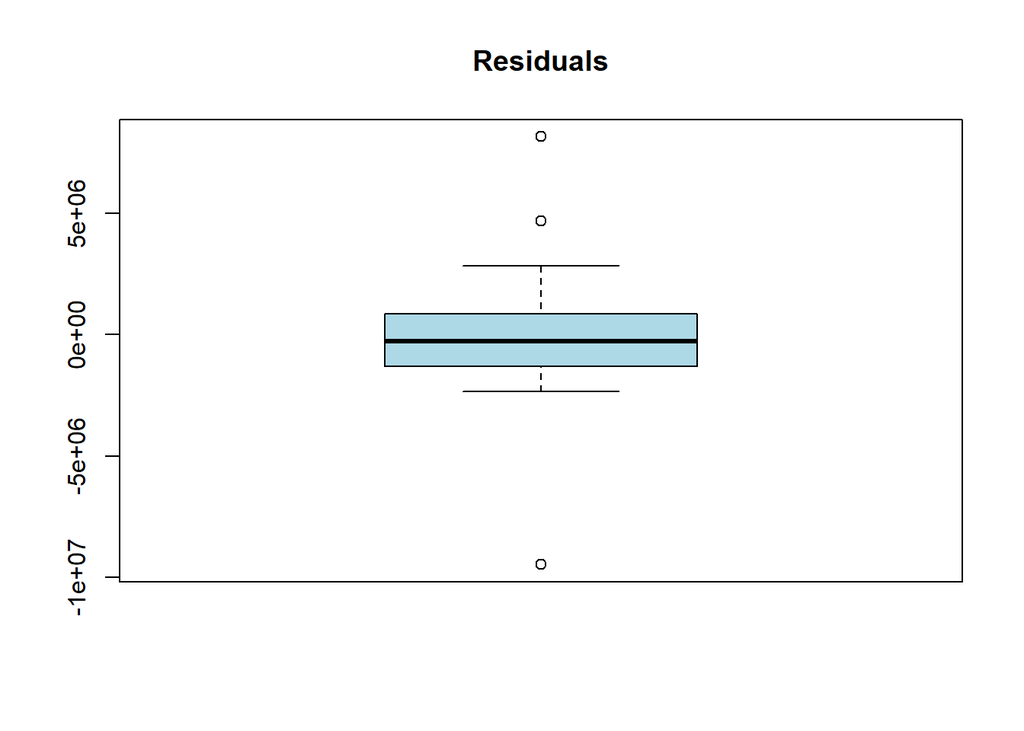

```r
pred = predict(model1,model_df)
res = pred - model_df$total_cases
boxplot(res,main = "Residuals", col = 'lightblue')
```

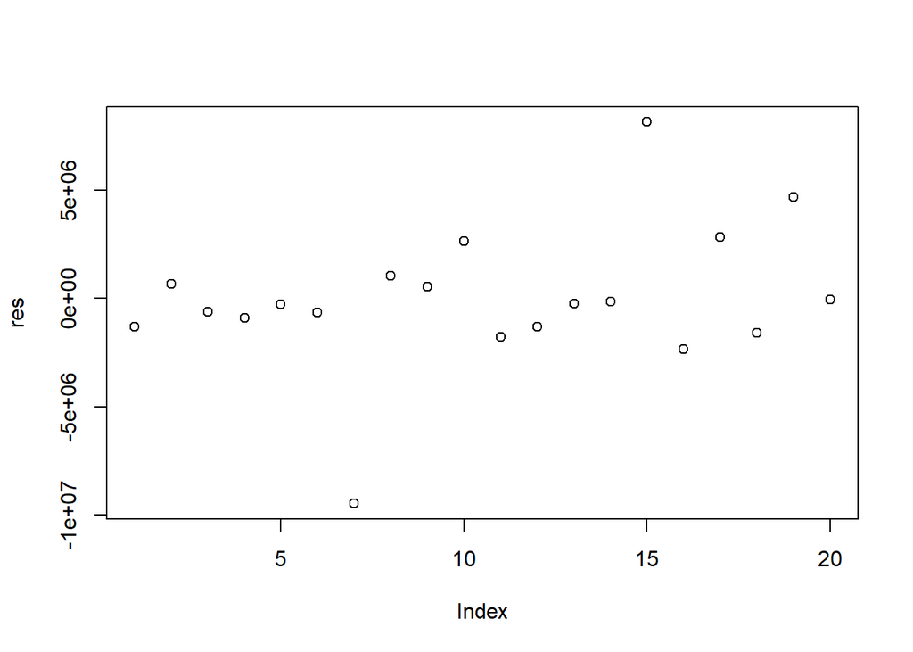

```r
plot(res)
```

```r
model2 = lm(total_cases~pop+gdp_pps+pop_dens,model_df[,-1])
summary(model2)
```

```
##
## Call:
## lm(formula = total_cases ~ pop + gdp_pps + pop_dens, data = model_df[,
##     -1])
##
## Residuals:
##      Min       1Q   Median       3Q      Max
## -8292012 -1088691   -80174  1655833  8962156
##
## Coefficients:
##               Estimate Std. Error t value Pr(>|t|)
## (Intercept) -3.877e+06  2.788e+06  -1.390    0.183
## pop          4.285e-01  3.677e-02  11.654 3.14e-09 ***
## gdp_pps      2.837e+04  2.560e+04   1.108    0.284
## pop_dens     6.499e+02  2.433e+03   0.267    0.793
## ---
## Signif. codes:  0 '***' 0.001 '**' 0.01 '*' 0.05 '.' 0.1 ' ' 1
##
## Residual standard error: 3708000 on 16 degrees of freedom
## Multiple R-squared:  0.8963, Adjusted R-squared:  0.8768
## F-statistic: 46.08 on 3 and 16 DF,  p-value: 4.268e-08
```

This model comes with an adjusted R^2 of 0.8768, meaning 87.68% of variation in new cases are explained by the model. However, still the population is a significant predictor in our model, and other coefficients including the intercept are insignificant under the critical value of 0.05.

```r
# The code below defines our 'newdata' data frame for applying our model to the
# population, population density and GDP per capita for two (2). Please execute
# the code as given.

newdata <- data.frame(country = c("Luxembourg", "Netherlands"),
                      pop = c(626108, 17407585),
                      gdp_pps = c(261, 130),
                      pop_dens = c(626108, 17407585) / c(2586, 41540))

# Add code here returning the actual  total cases from our dataset for the
# Netherlands and Luxembourg.

test_df  <- data %>%
  select(c(countriesAndTerritories, cases)) %>%
  group_by(countriesAndTerritories) %>%
  dplyr::summarize(total_cases = sum(cases, na.rm = TRUE)) %>%
  filter(countriesAndTerritories %in% c("Luxembourg", "Netherlands")) %>%
  select(total_cases)

pred = predict(model2,newdata)
res = pred - test_df

# Add code here returning the total cases for the Netherlands and Luxembourg
# predicted by our model.
cbind(pred,res)
```

```
##      pred total_cases
## 1 3954252   3653221.4
## 2 7543125   -951580.1
```

We then predict the model with a testing dataset of Luxembourg and Netherlands, the residuals are relatively large compared to the total cases, indicating inaccurate prediction of our model.

Then we consider other factors that might influence the total case, the total cases will surely be correlated to the previous total cases.

```r
demo = as.data.frame(cbind(twenty_countries,sq_km,gdp_pps)) %>% rename(country = twenty_countries)
model_df1 <- data %>%
  filter(countriesAndTerritories %in% twenty_countries) %>%
  rename(country = countriesAndTerritories) %>%
  left_join(demo,by = 'country') %>%
  group_by(country) %>%
  arrange(dateRep, .by_group = TRUE) %>%
  mutate(total_cases = cumsum(cases)) %>%
  mutate(lagged1_total_cases = lag(total_cases, n = 1, order_by = dateRep)) %>%

  ungroup() %>%
  mutate(across(everything(), ~ replace_na(., 0)))


model_df1 = model_df1[-c(1:5,7:9)]
model_df1[] <- lapply(model_df1, function(x) as.numeric(as.character(x)))

model_df1$pop_dens = model_df1$popData2020 / model_df1$sq_km
```

We then plot for partial autocorrelation for total cases by date, it shows a strong positive correlation between total cases and total cases one day ago, therefore we can try an autoregression model with total cases one day ago, and other parameters.

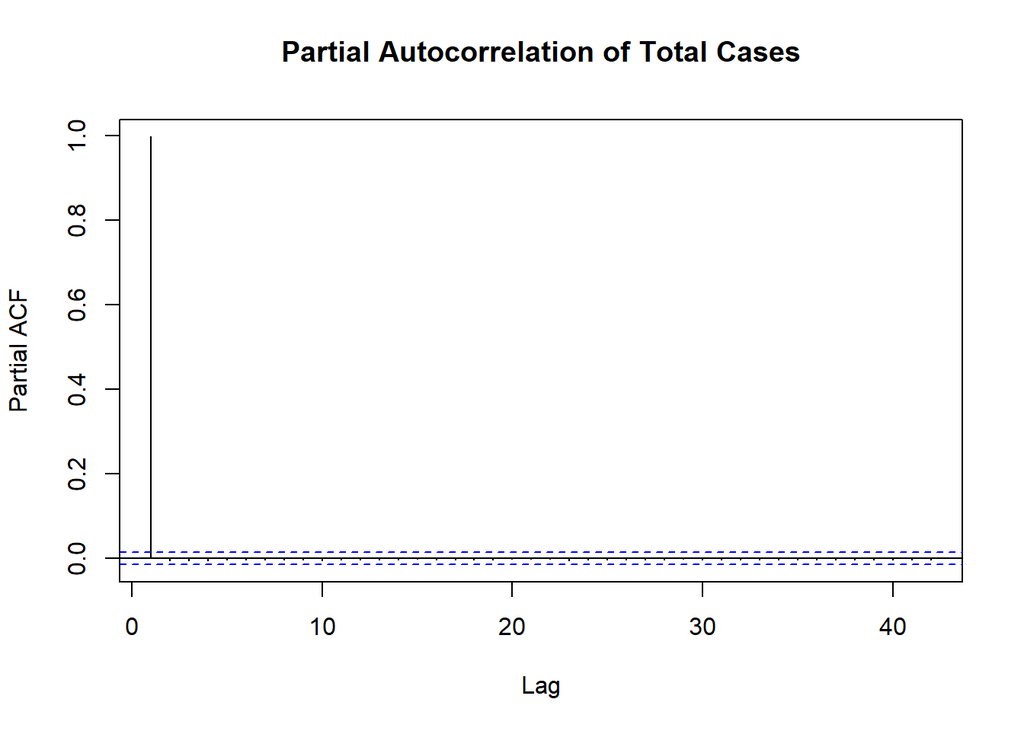

```r
pacf(model_df1$total_cases,main = "Partial Autocorrelation of Total Cases")
```

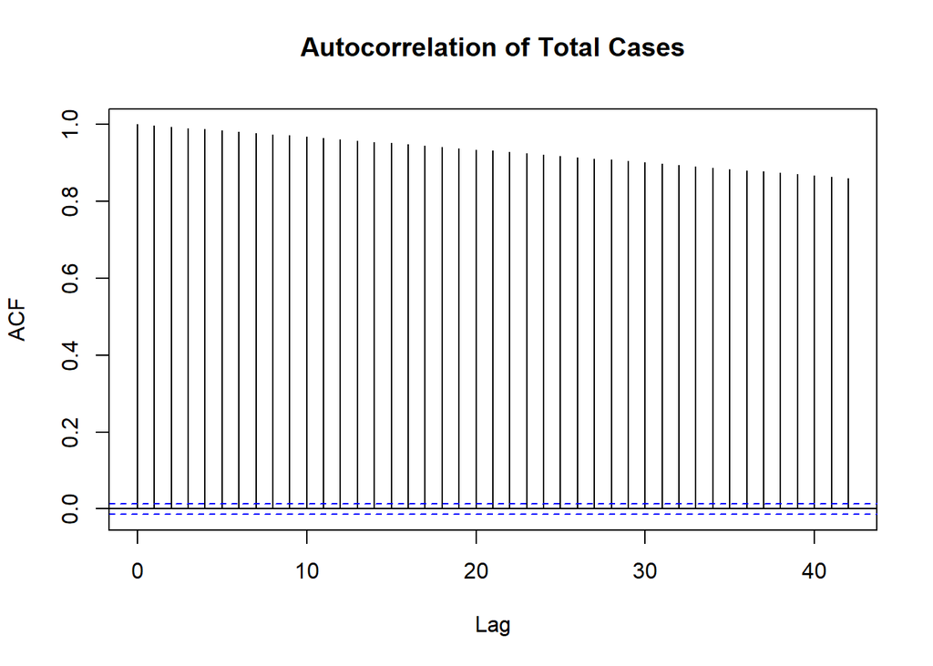

```r
acf(model_df1$total_cases,main = "Autocorrelation of Total Cases")
```

```r
lm.t = lm(total_cases~.,model_df1[-c(1,3,4,5)])
summary(lm.t)
```

```
##
## Call:
## lm(formula = total_cases ~ ., data = model_df1[-c(1, 3, 4, 5)])
##
## Residuals:
##    Min     1Q Median     3Q    Max
## -83520  -2953   -515    848 453444
##
## Coefficients:
##                       Estimate Std. Error   t value Pr(>|t|)
## (Intercept)         -2.600e+03  4.762e+02    -5.461 4.78e-08 ***
## popData2020          1.822e-04  7.398e-06    24.635  < 2e-16 ***
## gdp_pps              1.816e+01  4.361e+00     4.165 3.13e-05 ***
## lagged1_total_cases  1.002e+00  3.418e-05 29315.624  < 2e-16 ***
## pop_dens             4.798e-01  4.135e-01     1.160    0.246
## ---
## Signif. codes:  0 '***' 0.001 '**' 0.01 '*' 0.05 '.' 0.1 ' ' 1
##
## Residual standard error: 19570 on 19175 degrees of freedom
## Multiple R-squared:      1,  Adjusted R-squared:      1
## F-statistic: 3.072e+08 on 4 and 19175 DF,  p-value: < 2.2e-16
```

This model has an adjusted R^2 of 1, meaning that almost all variations in total cases are captured by our model. The coefficients are all significant except population density. The GDP per capita and population have positive coefficients, implying that an increase in these two will also be expected to increase in total cases. The coefficient of total cases on day ago is 1.002, this might imply a natural daily growth rate of 0.2% of Covid cases. If we move 1 unit of lagged total cases to the left of the estimation equation, it will become an OLS estimation of new cases.

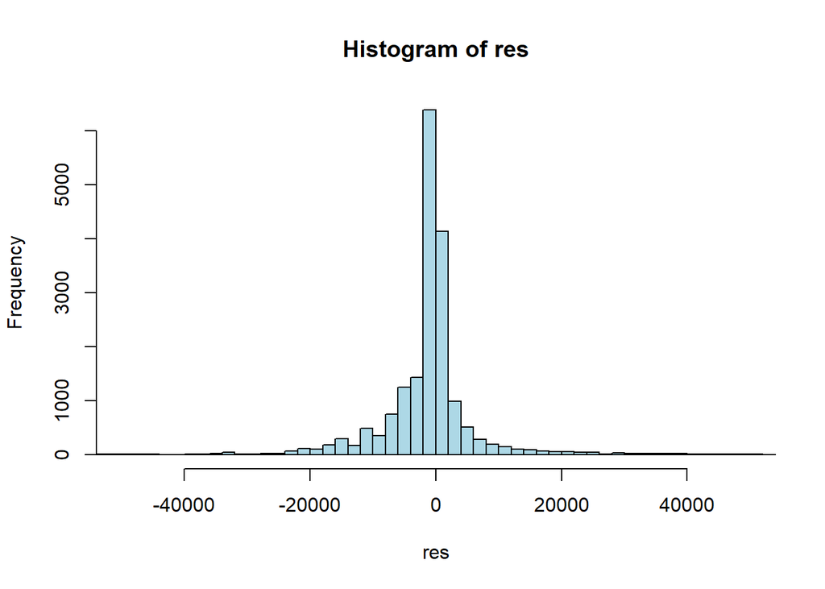

```r
res = model_df1$total_cases - predict(lm.t,model_df1)
hist(res,breaks = 200,xlim = c(-50000,50000), col="lightblue")
```

```r
demo.t =  data.frame(country = c("Luxembourg", "Netherlands"),
                      pop = c(626108, 17407585),
                      gdp_pps = c(261, 130),
                      pop_dens = c(626108, 17407585) / c(2586, 41540))
df.t <- data %>%
  filter(countriesAndTerritories %in% c("Luxembourg", "Netherlands")) %>%
  rename(country = countriesAndTerritories) %>%
  left_join(demo.t,by = 'country') %>%
  group_by(country) %>%
  arrange(dateRep, .by_group = TRUE) %>%
  mutate(total_cases = cumsum(cases)) %>%
  mutate(lagged1_total_cases = lag(total_cases, n = 1, order_by = dateRep)) %>%
  ungroup() %>%
  mutate(across(everything(), ~ replace_na(., 0)))


df.t = df.t[-c(1:5,7:9)]
df.t[] <- lapply(df.t, function(x) as.numeric(as.character(x)))
```

```r
res.t = df.t$total_cases - predict(lm.t,df.t)
sqrt(mean(res.t^2))
```

```
## [1] 13704.12
```

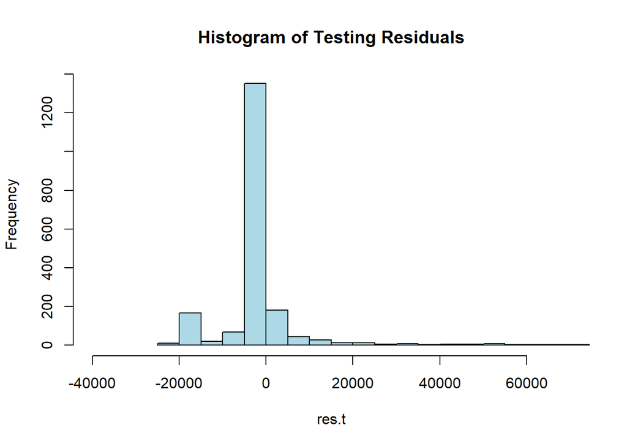

```r
hist(res.t,100,xlim = c(-40000,70000),main = "Histogram of Testing Residuals",col = "lightblue")
```

When we look into the causal effects, the models indicate a positive relationship of GDP per capita to the total cases, while in our general intuition, GDP as an indicator of development of the health system, should be expected to have a restricted effect on total cases. In our previous model, the effect of GDP on total cases might be confounded by the other columns, like GDP is correlated to population, population density and even total cases. Therefore we can try a double random forest model, estimating the unbiased effect of gdp_pps on total_cases:

```r
library(randomForest)
set.seed(1)
# Random Forest model for treatment
df = model_df1
rf_treatment <- randomForest(gdp_pps ~ ., data = df[-c(1,3,4,5,7)], ntree = 500)

# Random Forest model for outcome
rf_outcome <- randomForest(total_cases ~ ., data = df[-c(1,3,4,5,6)], ntree = 500)

# Predict treatment probabilities
df$treatment_res <- df$gdp_pps-predict(rf_treatment, df)

# Predict outcomes
df$predicted_res <- df$total_cases - predict(rf_outcome, df)

# Estimating Treatment Effect of gdp_pps to total_cases
summary(lm(predicted_res~treatment_res,df))
```

```
##
## Call:
## lm(formula = predicted_res ~ treatment_res, data = df)
##
## Residuals:
##      Min       1Q   Median       3Q      Max
## -4265897  -129453   -19616    90436 10039489
##
## Coefficients:
##               Estimate Std. Error t value Pr(>|t|)
## (Intercept)     -739.9     8605.3  -0.086   0.9315
## treatment_res -74953.3    35576.7  -2.107   0.0351 *
## ---
## Signif. codes:  0 '***' 0.001 '**' 0.01 '*' 0.05 '.' 0.1 ' ' 1
##
## Residual standard error: 1192000 on 19178 degrees of freedom
## Multiple R-squared:  0.0002314,  Adjusted R-squared:  0.0001793
## F-statistic: 4.439 on 1 and 19178 DF,  p-value: 0.03515
```

Interestingly in this model, we can also find a significant effect of gdp_ppps on total cases, but in negative value. This implies an improvement in the healthcare system, which can be indicated by GDP per capita, can cause reduction in the total covid cases. To improve our model, some instrumental variables that help more explain the development of the healthcare system like number of hospitals, number of nurses can be applied.